# Fluconazole data analysis

R. Cunning

2024-06-27

```r
# Load libraries
library(gam)
library(tidyverse)
library(lubridate)
library(janitor)

# Create custom ggplot theme
theme_custom <- function() {
  theme_bw(base_size = 10, base_family = "Arial") %+replace%
    theme(
      panel.grid.major = element_blank(),
      panel.grid.minor = element_blank(),
      panel.background = element_blank(),
      panel.border = element_rect(color = "black", fill = NA),
      legend.background = element_rect(fill = NA, colour = NA),
      axis.title = element_text(size = 7),
      axis.text = element_text(size = 5)
    )
}

# Function to pivot PAM data to long form with column for AOI
ipam_convert <- function(data) {
  data %>% select_if(~ !any(is.na(.))) %>%
    pivot_longer(cols = starts_with("f") | starts_with("y")) %>%
    separate(name, into = c("var", "aoi"), sep = "(?<=[A-Za-z_])(?=[0-9])")
}
```

```r
# Import PAM data
# List files with exported PAM data
pamfiles <- list.files(path = "data", pattern = "*.csv", full.names = T)

# Import data from each file
pam1 <- pamfiles %>%
  map_dfr(read_delim, delim = ";", .id = "file_id") %>%
  janitor::clean_names() %>%
  mutate(file_id = basename(pamfiles[as.numeric(file_id)]),
         date = as_date(date, format = "%d.%m.%y"))

# For files that have multiple sat pulses -- keep the last one only
pam1 <- pam1 %>%
  group_by(file_id, date) %>%
  filter(no == max(no)) %>%
  ungroup()

# For each source file, convert to long form data with F, FM, and YII for each AOI
pam1 <- pam1 %>%
  nest(-file_id, -date) %>%
  mutate(data2 = map(data, ipam_convert)) %>%
  unnest(data2) %>%
  group_by(file_id, date) %>%
  select(file_id, date, time, aoi, var, value) %>%
  mutate(aoi=as.numeric(aoi))

# Import metadata: order in which racks PAMmed, and order of genets on racks
pammd <- readxl::read_xlsx("Coral project part 2 data file.xlsx") %>%
  mutate(date = as_date(date)) %>%
  drop_na()

pammd<-pammd %>%
  crossing(aoi=c(1,2,3)) %>%
  mutate(aoi=((position-1)*3)+aoi)

# Join PAM data with rack order information (which PAM file corresponds to which rack of corals)
pam <- full_join(pam1, pammd) %>%
  group_by(file_id, date)

# Change treatment to a categorical variable
pam <- pam %>%
  mutate(treatment = factor(treatment, levels = c("0", "1", "5.3")))

# Check if any data and metadata did not match...(should be empty)
anti_join(pam1, pammd)
```

```
## # A tibble: 0 × 6
## # Groups:   file_id, date [0]
## # ℹ 6 variables: file_id <chr>, date <date>, time <time>, aoi <dbl>, var <chr>,
## #   value <dbl>
```

```r
# Subset just the Fv/Fm data (YII)
yii <- pam %>%
  filter(var=="y_ii_")

# Write processed Fv/Fm data to file
write_csv(yii,"output/fvfm_processed.csv")
```

# Bryopsis Fv/Fm

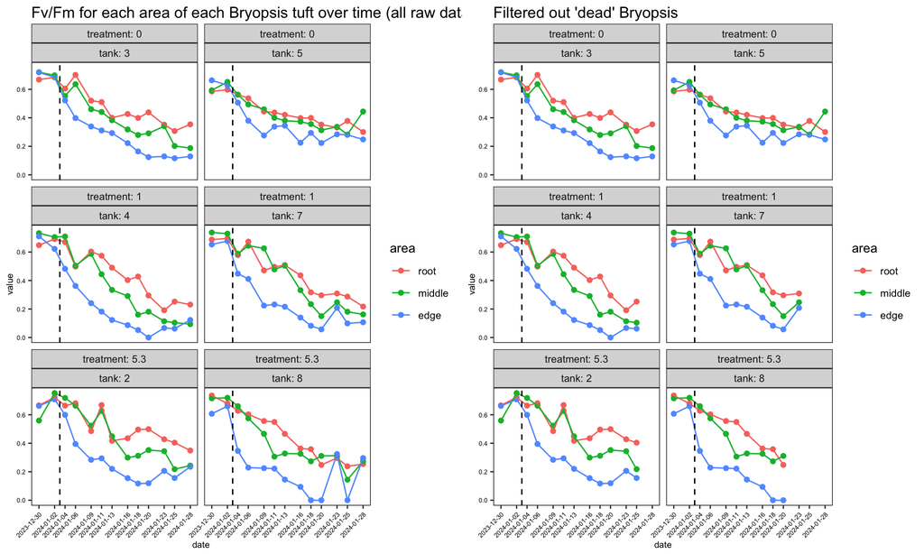

```r
# Create subset of data for just Bryopsis
bry <- yii %>%
  filter(species=="Bryopsis") %>%
  mutate(area = case_when(aoi == 1 ~ "root",
                          aoi == 2 ~ "middle",
                          aoi == 3 ~ "edge"),
         area = factor(area, levels = c("root", "middle", "edge")))

# Filter out dead Bryopsis data
bryf <- bry %>%
  filter(!(tank == 4 & date > "2024-01-25"),
         !(tank == 7 & date > "2024-01-23"),
         !(tank == 2 & date > "2024-01-25"),
         !(tank == 8 & date > "2024-01-20"))

# Plot all Bryopsis fv/fm data
bryfig1 <- ggplot(bry, aes(x = date, y = value, group = area, color = area)) +
  geom_point() +
  geom_line() +
  geom_vline(aes(xintercept = as_date("2024-01-03")), lty = 2) +
  facet_wrap(~ treatment + tank, nrow = 3,
             labeller = labeller(.rows = label_both)) +
  scale_x_date(breaks = unique(bry$date)) +
  theme_custom() +
  theme(axis.text.x = element_text(angle = 45, hjust = 1))

ggsave(filename = "output/bryfig1.png", plot = bryfig1,
       width = 120, height = 160, units = "mm")

bryfig1 <- bryfig1 +
  labs(title = "Fv/Fm for each area of each Bryopsis tuft over time (all raw data)")

filtered_bryfig1 <- bryfig1 %+% bryf +
  labs(title = "Filtered out 'dead' Bryopsis")

cowplot::plot_grid(bryfig1, filtered_bryfig1)
```

```r
# Use filtered data for analysis
bry <- bryf
```

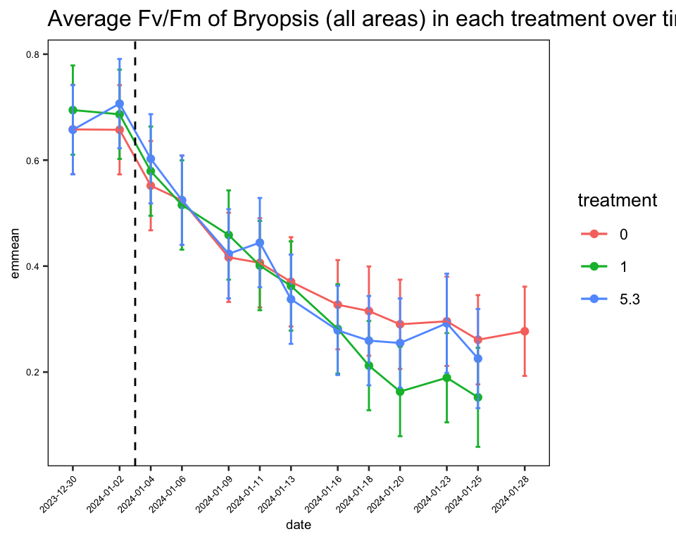

```r
# Linear model for fv/fm in Bryopsis at end of experiment
library(lme4)
# Fit linear mixed model with treatment and date as fixed predictors, and tank as random
mod <- lmer(value ~ treatment * factor(date) + (1|tank/area), data = bry)

# Calculate the "marginal means" of each treatment on each date
library(emmeans)
all <- emmeans(mod, specs = "treatment", by = "date", level = 0.87)
res <- as_tibble(all)

# Plot means for each treatment over time
# Plot overall mean for each treatment over time
res %>%
  ggplot(aes(x = date, y = emmean, group = treatment, color = treatment)) +
  geom_point() +
  geom_errorbar(aes(ymin = lower.CL, ymax = upper.CL), width = 0.3) +
  geom_line() +
  geom_vline(aes(xintercept = as_date("2024-01-03")), lty = 2) +
  scale_x_date(breaks = unique(bry$date)) +
  theme_custom() +
  theme(axis.text.x = element_text(angle = 45, hjust = 1)) +
  labs(title = "Average Fv/Fm of Bryopsis (all areas) in each treatment over time")
```

```r
# Test for differences between treatments on each date
pwtests <- as_tibble(contrast(all, "pairwise"))

# When do we see statistical differences between treatments?
sig <- pwtests %>% filter(p.value < 0.05)
knitr::kable(sig)
```

| contrast | date | estimate | SE | df | t.ratio | p.value |
| --- | --- | --- | --- | --- | --- | --- |

When looking at overall average Fv/Fm for Bryopsis, there are no significant treatment effects, and confidence intervals are very wide… Let’s look at just the edges of Bryopsis to see if anything clearer emerges.

### Just the edges of Bryopsis

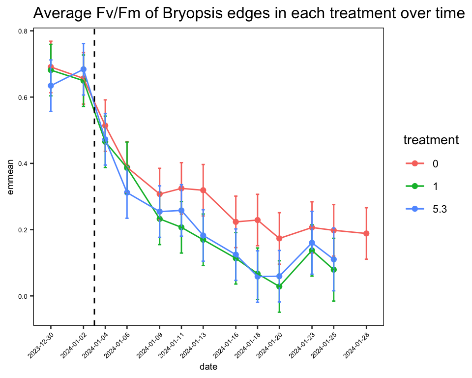

```r
# Fit linear mixed model with treatment and date as fixed predictors, and tank as random
edges <- lmer(value ~ treatment * factor(date) + (1|tank),
             data = filter(bry, area == "edge"))
# Means at each individual date
alledges <- emmeans(edges, specs = "treatment", by = "date", level = 0.87)

# Statistically compare these marginal means through pairwise contrasts
resedges <- as_tibble(contrast(alledges, "pairwise", adjust = "none"))

# When do we see significant differences by treatment in the edges?
sigedges <- resedges %>%
  filter(p.value < 0.05)

as_tibble(alledges) %>%
  ggplot(aes(x = date, y = emmean, color = treatment, value = treatment)) +
  geom_point() +
  geom_errorbar(aes(ymin = lower.CL, ymax = upper.CL), width = 0.3) +
  geom_line() +
  geom_vline(aes(xintercept = as_date("2024-01-03")), lty = 2) +
  scale_x_date(breaks = unique(bry$date)) +
  theme_custom() +
  theme(axis.text.x = element_text(angle = 45, hjust = 1)) +
  labs(title = "Average Fv/Fm of Bryopsis edges in each treatment over time")
```

```r
knitr::kable(sigedges)
```

| contrast | date | estimate | SE | df | t.ratio | p.value |
| --- | --- | --- | --- | --- | --- | --- |
| treatment0 - treatment1 | 2024-01-13 | 0.1495 | 0.0670924 | 10.96692 | 2.228270 | 0.0477401 |
| treatment0 - treatment1 | 2024-01-18 | 0.1620 | 0.0670924 | 10.96692 | 2.414580 | 0.0343966 |
| treatment0 - treatment5.3 | 2024-01-18 | 0.1705 | 0.0670924 | 10.96692 | 2.541271 | 0.0274741 |

The 1 mg/ml and 5.3 mg/ml treatments also don’t look that different from one another, so we could combine these into “treated” vs. “untreated” (controls) to increase statistical power…

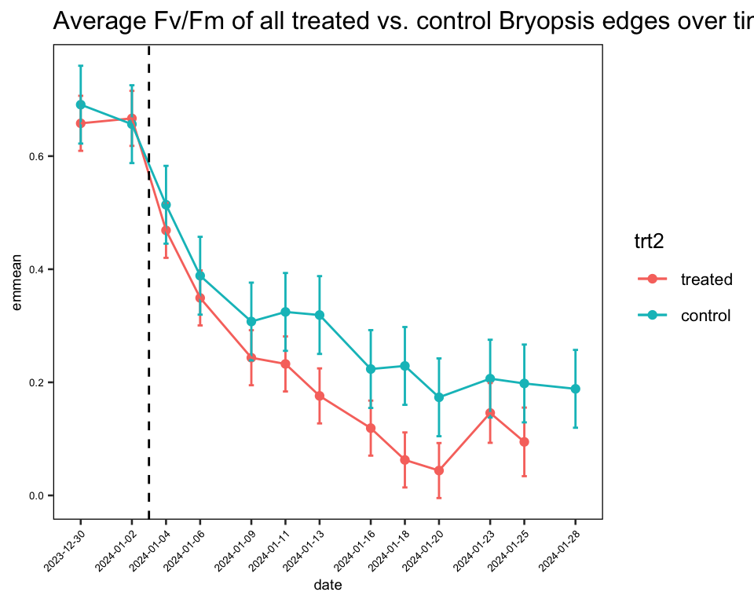

```r
#### Compare 2 control tanks vs. 4 "treated" tanks
bry2 <- bry %>%
  mutate(trt2 = case_when(as.numeric(as.character(treatment)) == 0 ~ "control",
                          as.numeric(as.character(treatment)) > 0  ~ "treated"),
         trt2 = factor(trt2))
# Fit linear mixed model with treatment and date as fixed predictors, and tank as random
mod<-lmer(value~trt2*factor(date)+(1|tank),data=filter(bry2, area == "edge"))
# Means at each individual date
alltrt2 <- emmeans(mod, specs = "trt2", by = "date", level = 0.87)
# Statistically compare these marginal means through pairwise contrasts
restrt2 <- contrast(alltrt2, "pairwise", adjust = "none")
# there are differences between control and 4xtreated tanks, when looking at Bryopsis tips only

as_tibble(alltrt2) %>%
  ggplot(aes(x = date, y = emmean, group = trt2, color = trt2)) +
  geom_point() +
  geom_errorbar(aes(ymin = lower.CL, ymax = upper.CL), width = 0.3) +
  geom_line() +
  geom_vline(aes(xintercept = as_date("2024-01-03")), lty = 2) +
  scale_x_date(breaks = unique(bry$date)) +
  theme_custom() +
  theme(axis.text.x = element_text(angle = 45, hjust = 1)) +
  labs(title = "Average Fv/Fm of all treated vs. control Bryopsis edges over time")
```

```r
sigtrt2 <- as_tibble(restrt2) %>%
  filter(p.value < 0.05)

# When do we see significant differences between control and treated?
knitr::kable(sigtrt2)
```

| contrast | date | estimate | SE | df | t.ratio | p.value |
| --- | --- | --- | --- | --- | --- | --- |
| treated - control | 2024-01-13 | -0.14300 | 0.0527927 | 16.00049 | -2.708706 | 0.0154929 |
| treated - control | 2024-01-18 | -0.16625 | 0.0527927 | 16.00049 | -3.149107 | 0.0062066 |
| treated - control | 2024-01-20 | -0.12950 | 0.0527927 | 16.00049 | -2.452989 | 0.0260162 |

Combining the treated tanks together, we see that Bryopsis Fv/Fm (edges) is significantly lower in treated tanks vs. control on Jan. 13th, 18th, and 20th.

# Coral Fv/Fm

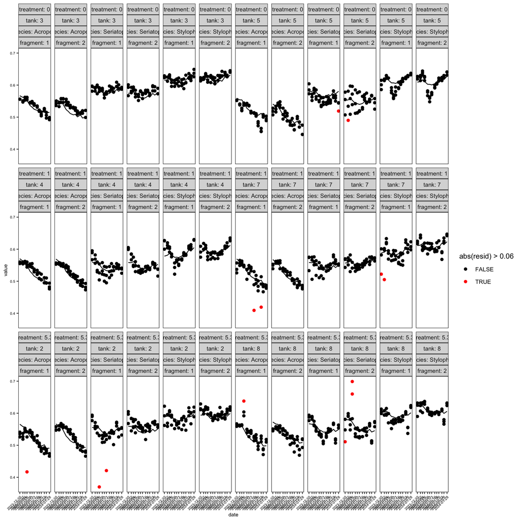

```r
# Create subset of data for just coral
coral <- yii %>%
  filter(species != "Bryopsis")


# Plot all coral fv/fm data
coralplot <- ggplot(coral, aes(x = date, y = value)) +
  geom_point() +
  facet_wrap(~ treatment + tank + species + fragment, nrow = 3,
             labeller = labeller(.rows = label_both)) +
  scale_x_date(breaks = unique(bry$date)) +
  theme_custom() +
  theme(axis.text.x = element_text(angle = 45, hjust = 1))

# Identify outliers by smooth function
mod <- gam(value ~ s(date, spar = 0) * treatment * species * tank:fragment, data = coral)

# Plot data with outliers shown
coral <- coral %>%
  ungroup() %>%
  mutate(resid = residuals(mod),
         fit= fitted(mod))

ggplot(coral, aes(x = date, y = value)) +
  geom_point(aes(color = abs(resid) > 0.06)) +
  geom_line(aes(y = fit)) +
  facet_wrap(~ treatment + tank + species + fragment, nrow = 3,
             labeller = labeller(.rows = label_both)) +
  scale_x_date(breaks = unique(bry$date)) +
  scale_color_manual(values = c("black", "red")) +
  theme_custom() +
  theme(axis.text.x = element_text(angle = 45, hjust = 1))
```

```r
# Filter outliers
coral <- coral %>%
  filter(abs(resid) < 0.06)
```

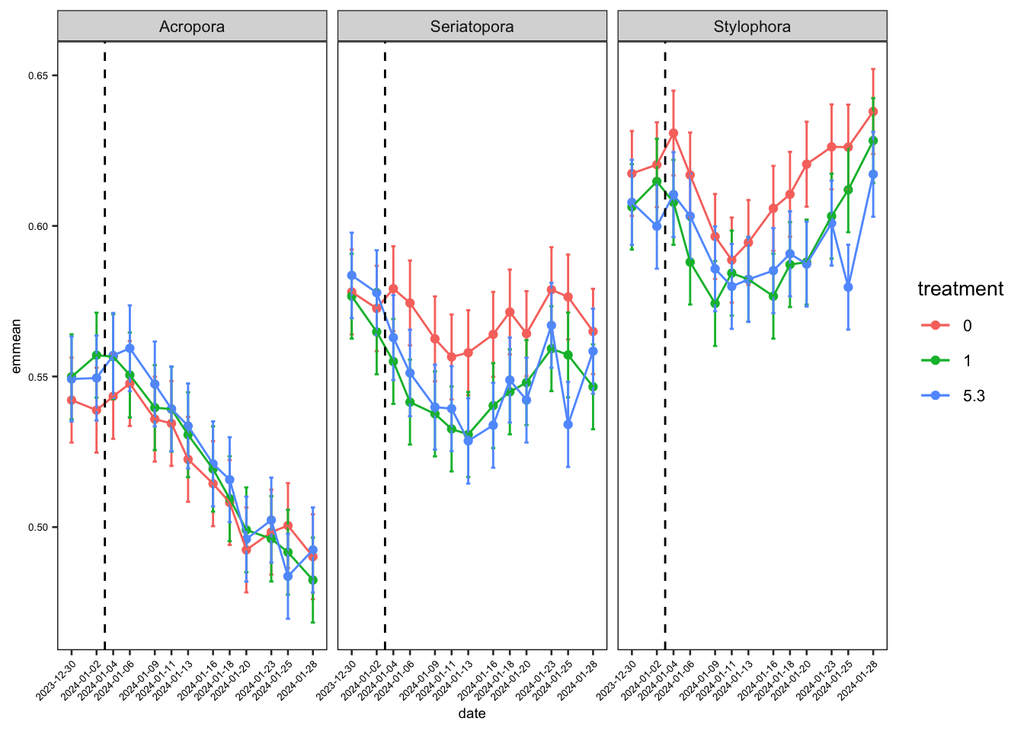

```r
mod <- lmer(value ~ factor(date) * treatment * species + (1|tank/species/fragment),
            data = coral)

emm <- emmeans(mod, specs = "treatment", by = c("species", "date"), level = 0.87)

as_tibble(emm) %>%
  ggplot(aes(x = date, y = emmean, color = treatment, group = treatment)) +
  geom_point() +
  geom_errorbar(aes(ymin = lower.CL, ymax = upper.CL), width = 0.5) +
  geom_line() +
  scale_x_date(breaks = unique(bry$date)) +
  facet_wrap(~species) +
  theme_custom() +
  theme(axis.text.x = element_text(angle = 45, hjust = 1)) +
  geom_vline(aes(xintercept = as_date("2024-01-03")), lty = 2)
```

```r
res <- as_tibble(contrast(emm, "pairwise", adjust = "none"))
res %>%
  filter(p.value < 0.05) %>%
  arrange(species, date) %>%
  knitr::kable()
```

| contrast | species | date | estimate | SE | df | t.ratio | p.value |
| --- | --- | --- | --- | --- | --- | --- | --- |
| treatment0 - treatment1 | Seriatopora | 2024-01-06 | 0.0329167 | 0.0116525 | 7.129263 | 2.824856 | 0.0251115 |
| treatment0 - treatment5.3 | Seriatopora | 2024-01-13 | 0.0292949 | 0.0117090 | 7.268160 | 2.501921 | 0.0396733 |
| treatment0 - treatment5.3 | Seriatopora | 2024-01-16 | 0.0301667 | 0.0116525 | 7.129263 | 2.588856 | 0.0354418 |
| treatment0 - treatment5.3 | Seriatopora | 2024-01-25 | 0.0423333 | 0.0116525 | 7.129263 | 3.632980 | 0.0081053 |
| treatment0 - treatment1 | Stylophora | 2024-01-06 | 0.0289167 | 0.0116525 | 7.129263 | 2.481583 | 0.0415129 |
| treatment0 - treatment1 | Stylophora | 2024-01-16 | 0.0291667 | 0.0116525 | 7.129263 | 2.503037 | 0.0402182 |
| treatment0 - treatment1 | Stylophora | 2024-01-20 | 0.0325000 | 0.0116525 | 7.129263 | 2.789099 | 0.0264485 |
| treatment0 - treatment5.3 | Stylophora | 2024-01-20 | 0.0331667 | 0.0116525 | 7.129263 | 2.846311 | 0.0243435 |
| treatment0 - treatment5.3 | Stylophora | 2024-01-25 | 0.0465000 | 0.0116525 | 7.129263 | 3.990556 | 0.0050602 |
| treatment1 - treatment5.3 | Stylophora | 2024-01-25 | 0.0323333 | 0.0116525 | 7.129263 | 2.774796 | 0.0270040 |

Acropora corals showed a ~10% decline in Fv/Fm over time, but this occurred in all treatments and the control, so there is no effect of treatment on Fv/Fm in Acropora.